# Assigning ASVs with DADA2

Roger Calvas

2026-09-15

# Setear variables de ambientes

## Semilla y threads

```r
# Set the seed for reproducibility
set.seed(9473)

# Let's make a parameter to set the number of threads
n_threads = 20
```

## Tiempo de inicio

```r
# What time did we start running this script?
start_time <- Sys.time()
```

## Load Packages

```r
#install.packages("janitor")
# Efficient package loading with pacman
pacman::p_load(tidyverse, devtools, dada2,
               patchwork, DT, phyloseq, janitor, install = FALSE)
```

# Objetivos del archivo:

1. Inferir el modelo de error de DADA2 tanto en las R1 como R2
2. Asignar ASVs usando el modelo de error tanto en R1 como R2
3. Empalmar las secuencias para generar una tabla de ASVs continua
4. Crear el primer draft de la tabla de recuento de ASVs
5. Chequear estadistica de ASVs
6. Quitar quimeras
7. Asignar taxonomia con UNITE
8. Guardar los archivos relevantes: `asv_table`, `asvs_fasta`, `tax_table`, y `sample_data`
9. Crear S4 R data object, en este caso llamado phyloseq, desde la tabla `asv_table`, `tax_table`, y metadata.Unificando todo en un solo objeto de datos.

## Input

1. Fastq filtrados de `01_QC_DADA2.Rmd`
2. Vector de sample_names
3. Metadata

## Output

1. Tabla de conteo de asvs: `asv_table` (Con y sin nombre de secuencia)
2. Tabla de taxonomia asignada `tax_table`
3. Un objeto phyloseq raw (S4 object): `raw_physeq.RData`

# Cargar datos

## Cargar fastqs

```r
# Place filtered seq files into a variable
filtered_fastqs_path <- "data/its/01_DADA2/filtered_fastqs"

# Intuition check:
filtered_fastqs_path
```

```
## [1] "data/its/01_DADA2/filtered_fastqs"
```

```r
# Create Forward vector
filtered_forward_reads <-
  list.files(filtered_fastqs_path, pattern = "R1_filtered.fastq.gz",
             full.names = TRUE)
# Check
filtered_forward_reads[1:5]
```

```
## [1] "data/its/01_DADA2/filtered_fastqs/ANF-004_R1_filtered.fastq.gz"
## [2] "data/its/01_DADA2/filtered_fastqs/ANF-006_R1_filtered.fastq.gz"
## [3] "data/its/01_DADA2/filtered_fastqs/ANF-007_R1_filtered.fastq.gz"
## [4] "data/its/01_DADA2/filtered_fastqs/ANF-011_R1_filtered.fastq.gz"
## [5] "data/its/01_DADA2/filtered_fastqs/ANF-018_R1_filtered.fastq.gz"
```

```r
# Reverse vector
filtered_reverse_reads <-
    list.files(filtered_fastqs_path, pattern = "R2_filtered.fastq.gz",
             full.names = TRUE)

# Check
filtered_reverse_reads[1:5]
```

```
## [1] "data/its/01_DADA2/filtered_fastqs/ANF-004_R2_filtered.fastq.gz"
## [2] "data/its/01_DADA2/filtered_fastqs/ANF-006_R2_filtered.fastq.gz"
## [3] "data/its/01_DADA2/filtered_fastqs/ANF-007_R2_filtered.fastq.gz"
## [4] "data/its/01_DADA2/filtered_fastqs/ANF-011_R2_filtered.fastq.gz"
## [5] "data/its/01_DADA2/filtered_fastqs/ANF-018_R2_filtered.fastq.gz"
```

## Nombres de muestras

```r
# Create vector of sample names from the filenames
sample_names <- sapply(strsplit(basename(filtered_forward_reads), "_"), `[`, 1)

# Intuition Check
head(sample_names)
```

```
## [1] "ANF-004" "ANF-006" "ANF-007" "ANF-011" "ANF-018" "ANF-021"
```

# Prediccion de errores

## Funcion de estimacion para bins

```r
# Declarar los bins del secuenciador
binnedQs <- c(2, 11, 25, 37)

# Crear la funcion en base a los bins
binnedErrFun <- makeBinnedQualErrfun(binnedQs)
```

## Calcular los errores

```r
# Forward Reads con binned err fun
error_forward_reads <-
  learnErrors(filtered_forward_reads, multithread = n_threads, nbases = 3e8, errorEstimationFunction = binnedErrFun)
```

```
## 301323930 total bases in 1335234 reads from 23 samples will be used for learning the error rates.
```

```r
# Forward Error Plot
forward_error_plot <-
  plotErrors(error_forward_reads, nominalQ = TRUE) +
  labs(title = "Forward Reads: Error Model")

# Reverse Reads con binned err fun
error_reverse_reads <-
  learnErrors(filtered_reverse_reads, multithread = n_threads, nbases = 3e8, errorEstimationFunction = binnedErrFun)
```

```
## 308626572 total bases in 1384506 reads from 24 samples will be used for learning the error rates.
```

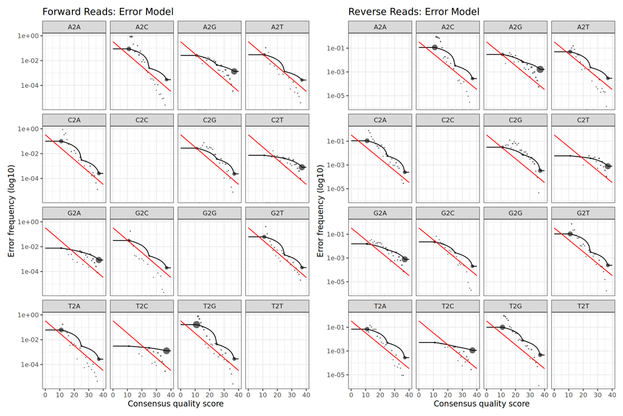

```r
# Reverse Error Plot
reverse_error_plot <-
  plotErrors(error_reverse_reads, nominalQ = TRUE) +
  labs(title = "Reverse Reads: Error Model")

# Look at the plots together
forward_error_plot + reverse_error_plot
```

Preguntas 1: La secuencia tenia calidades binned y como se ajusto la curva de error?

[La secuencia tenia bins en: ‘2, 11, 25, 37’ y la curva de error se ajusto mejor al aplicar el modelo para secuenciadores de bins]

# Inferir e inspeccionar ASVs

## Inferir ASVs

```r
# Infer ASVs on the forward sequences
dada_forward <-
  dada(filtered_forward_reads,
       err = error_forward_reads,
       multithread = n_threads)
```

```
## Sample 1 - 73782 reads in 19336 unique sequences.
## Sample 2 - 72925 reads in 20605 unique sequences.
## Sample 3 - 47866 reads in 9961 unique sequences.
## Sample 4 - 59592 reads in 15086 unique sequences.
## Sample 5 - 50036 reads in 9809 unique sequences.
## Sample 6 - 59449 reads in 10247 unique sequences.
## Sample 7 - 57917 reads in 13050 unique sequences.
## Sample 8 - 51600 reads in 10055 unique sequences.
## Sample 9 - 74518 reads in 21221 unique sequences.
## Sample 10 - 47780 reads in 8969 unique sequences.
## Sample 11 - 56162 reads in 8926 unique sequences.
## Sample 12 - 60487 reads in 10808 unique sequences.
## Sample 13 - 50095 reads in 5678 unique sequences.
## Sample 14 - 73776 reads in 18324 unique sequences.
## Sample 15 - 60728 reads in 7559 unique sequences.
## Sample 16 - 49560 reads in 7296 unique sequences.
## Sample 17 - 48285 reads in 8410 unique sequences.
## Sample 18 - 45641 reads in 9293 unique sequences.
## Sample 19 - 54228 reads in 9580 unique sequences.
## Sample 20 - 47922 reads in 8236 unique sequences.
## Sample 21 - 71054 reads in 16053 unique sequences.
## Sample 22 - 74618 reads in 12418 unique sequences.
## Sample 23 - 47213 reads in 10470 unique sequences.
## Sample 24 - 49272 reads in 9913 unique sequences.
## Sample 25 - 51286 reads in 7996 unique sequences.
## Sample 26 - 50865 reads in 8501 unique sequences.
## Sample 27 - 47565 reads in 8788 unique sequences.
## Sample 28 - 49098 reads in 6552 unique sequences.
## Sample 29 - 48915 reads in 9489 unique sequences.
## Sample 30 - 52395 reads in 7029 unique sequences.
## Sample 31 - 54830 reads in 6097 unique sequences.
## Sample 32 - 47762 reads in 11831 unique sequences.
## Sample 33 - 73444 reads in 20293 unique sequences.
## Sample 34 - 61922 reads in 10334 unique sequences.
```

```r
# Take a look at the data
# What type of data structure is it?
typeof(dada_forward) # It's a list
```

```
## [1] "list"
```

```r
length(dada_forward) # How big is it? One per sample!
```

```
## [1] 34
```

```r
# What doees it look like for each sample?
dada_forward$`ANF-004`
```

```
## dada-class: object describing DADA2 denoising results
## 293 sequence variants were inferred from 19336 input unique sequences.
## Key parameters: OMEGA_A = 1e-40, OMEGA_C = 1e-40, BAND_SIZE = 16
```

```r
# Reverse ASVs
dada_reverse <-
  dada(filtered_reverse_reads,
       err = error_reverse_reads ,
       multithread = n_threads)
```

```
## Sample 1 - 73782 reads in 19196 unique sequences.
## Sample 2 - 72925 reads in 19683 unique sequences.
## Sample 3 - 47866 reads in 11630 unique sequences.
## Sample 4 - 59592 reads in 21003 unique sequences.
## Sample 5 - 50036 reads in 12183 unique sequences.
## Sample 6 - 59449 reads in 12354 unique sequences.
## Sample 7 - 57917 reads in 14117 unique sequences.
## Sample 8 - 51600 reads in 10866 unique sequences.
## Sample 9 - 74518 reads in 23034 unique sequences.
## Sample 10 - 47780 reads in 10099 unique sequences.
## Sample 11 - 56162 reads in 10032 unique sequences.
## Sample 12 - 60487 reads in 11074 unique sequences.
## Sample 13 - 50095 reads in 6102 unique sequences.
## Sample 14 - 73776 reads in 20047 unique sequences.
## Sample 15 - 60728 reads in 6481 unique sequences.
## Sample 16 - 49560 reads in 8240 unique sequences.
## Sample 17 - 48285 reads in 9552 unique sequences.
## Sample 18 - 45641 reads in 11051 unique sequences.
## Sample 19 - 54228 reads in 11143 unique sequences.
## Sample 20 - 47922 reads in 10003 unique sequences.
## Sample 21 - 71054 reads in 16313 unique sequences.
## Sample 22 - 74618 reads in 14176 unique sequences.
## Sample 23 - 47213 reads in 10615 unique sequences.
## Sample 24 - 49272 reads in 10642 unique sequences.
## Sample 25 - 51286 reads in 9171 unique sequences.
## Sample 26 - 50865 reads in 9039 unique sequences.
## Sample 27 - 47565 reads in 9900 unique sequences.
## Sample 28 - 49098 reads in 7287 unique sequences.
## Sample 29 - 48915 reads in 10039 unique sequences.
## Sample 30 - 52395 reads in 9106 unique sequences.
## Sample 31 - 54830 reads in 19328 unique sequences.
## Sample 32 - 47762 reads in 12586 unique sequences.
## Sample 33 - 73444 reads in 21083 unique sequences.
## Sample 34 - 61922 reads in 11814 unique sequences.
```

```r
# Check data
dada_reverse[30]
```

```
## $`JCS-2137_R2_filtered.fastq.gz`
## dada-class: object describing DADA2 denoising results
## 176 sequence variants were inferred from 9106 input unique sequences.
## Key parameters: OMEGA_A = 1e-40, OMEGA_C = 1e-40, BAND_SIZE = 16
```

## Mergear los ASVs

```r
merged_ASVs <-
  mergePairs(dada_forward, filtered_forward_reads,
             dada_reverse, filtered_reverse_reads,
             verbose = TRUE)
```

```
## 71311 paired-reads (in 277 unique pairings) successfully merged out of 73307 (in 429 pairings) input.
```

```
## Duplicate sequences in merged output.
```

```
## 71122 paired-reads (in 147 unique pairings) successfully merged out of 72763 (in 213 pairings) input.
```

```
## 45836 paired-reads (in 197 unique pairings) successfully merged out of 47678 (in 230 pairings) input.
```

```
## Duplicate sequences in merged output.
```

```
## 56475 paired-reads (in 313 unique pairings) successfully merged out of 59288 (in 387 pairings) input.
```

```
## Duplicate sequences in merged output.
```

```
## 48427 paired-reads (in 220 unique pairings) successfully merged out of 49676 (in 319 pairings) input.
```

```
## Duplicate sequences in merged output.
```

```
## 58241 paired-reads (in 308 unique pairings) successfully merged out of 59245 (in 354 pairings) input.
```

```
## 57697 paired-reads (in 120 unique pairings) successfully merged out of 57824 (in 143 pairings) input.
```

```
## 51038 paired-reads (in 199 unique pairings) successfully merged out of 51486 (in 226 pairings) input.
```

```
## 71289 paired-reads (in 166 unique pairings) successfully merged out of 74147 (in 250 pairings) input.
```

```
## Duplicate sequences in merged output.
```

```
## 43604 paired-reads (in 89 unique pairings) successfully merged out of 47682 (in 118 pairings) input.
```

```
## 53776 paired-reads (in 170 unique pairings) successfully merged out of 55985 (in 210 pairings) input.
```

```
## Duplicate sequences in merged output.
```

```
## 59729 paired-reads (in 167 unique pairings) successfully merged out of 60323 (in 197 pairings) input.
```

```
## Duplicate sequences in merged output.
```

```
## 49446 paired-reads (in 50 unique pairings) successfully merged out of 50058 (in 59 pairings) input.
```

```
## 69447 paired-reads (in 121 unique pairings) successfully merged out of 73665 (in 191 pairings) input.
```

```
## 60461 paired-reads (in 85 unique pairings) successfully merged out of 60695 (in 100 pairings) input.
```

```
## 48369 paired-reads (in 143 unique pairings) successfully merged out of 49437 (in 176 pairings) input.
```

```
## 45031 paired-reads (in 174 unique pairings) successfully merged out of 48200 (in 220 pairings) input.
```

```
## 42898 paired-reads (in 142 unique pairings) successfully merged out of 45538 (in 199 pairings) input.
```

```
## Duplicate sequences in merged output.
```

```
## 48612 paired-reads (in 185 unique pairings) successfully merged out of 54146 (in 236 pairings) input.
```

```
## Duplicate sequences in merged output.
```

```
## 40666 paired-reads (in 170 unique pairings) successfully merged out of 47817 (in 218 pairings) input.
```

```
## Duplicate sequences in merged output.
```

```
## 69051 paired-reads (in 361 unique pairings) successfully merged out of 70726 (in 421 pairings) input.
```

```
## Duplicate sequences in merged output.
```

```
## 72968 paired-reads (in 259 unique pairings) successfully merged out of 74362 (in 313 pairings) input.
```

```
## Duplicate sequences in merged output.
```

```
## 45440 paired-reads (in 203 unique pairings) successfully merged out of 47144 (in 268 pairings) input.
```

```
## Duplicate sequences in merged output.
```

```
## 48414 paired-reads (in 185 unique pairings) successfully merged out of 49187 (in 232 pairings) input.
```

```
## 49715 paired-reads (in 122 unique pairings) successfully merged out of 51127 (in 148 pairings) input.
```

```
## 49938 paired-reads (in 97 unique pairings) successfully merged out of 50750 (in 119 pairings) input.
```

```
## Duplicate sequences in merged output.
```

```
## 45406 paired-reads (in 155 unique pairings) successfully merged out of 47462 (in 182 pairings) input.
```

```
## 48523 paired-reads (in 136 unique pairings) successfully merged out of 49002 (in 161 pairings) input.
```

```
## 45865 paired-reads (in 149 unique pairings) successfully merged out of 48763 (in 215 pairings) input.
```

```
## 51962 paired-reads (in 168 unique pairings) successfully merged out of 52295 (in 192 pairings) input.
```

```
## Duplicate sequences in merged output.
```

```
## 35646 paired-reads (in 127 unique pairings) successfully merged out of 54725 (in 143 pairings) input.
```

```
## 46065 paired-reads (in 365 unique pairings) successfully merged out of 47521 (in 412 pairings) input.
```

```
## Duplicate sequences in merged output.
```

```
## 71014 paired-reads (in 393 unique pairings) successfully merged out of 73048 (in 535 pairings) input.
```

```
## Duplicate sequences in merged output.
```

```
## 59673 paired-reads (in 173 unique pairings) successfully merged out of 61826 (in 217 pairings) input.
```

```
## Duplicate sequences in merged output.
```

```r
# Evaluate the data output
typeof(merged_ASVs) # A list
```

```
## [1] "list"
```

```r
length(merged_ASVs) # Length of the number of samples!
```

```
## [1] 34
```

```r
head(names(merged_ASVs)) # Here, we can access our current sample names
```

```
## [1] "ANF-004_R1_filtered.fastq.gz" "ANF-006_R1_filtered.fastq.gz"
## [3] "ANF-007_R1_filtered.fastq.gz" "ANF-011_R1_filtered.fastq.gz"
## [5] "ANF-018_R1_filtered.fastq.gz" "ANF-021_R1_filtered.fastq.gz"
```

```r
# Inspect further for each sample
head(merged_ASVs, n = 2) # A dataframe for each sample
```

[output not shown]

[output cut: 840 more lines]

```r
# We have a dataframe in each part of our list! What are in the columns?
glimpse(merged_ASVs$`ANF-004`)
```

```
## Rows: 277
## Columns: 9
## $ sequence  <chr> "CCCAAACGCGTGCCGGCGCTGAAAGTGAAACTCAAGGATTCGCCGGTGTACGTGGGCGT…
## $ abundance <int> 11776, 6047, 4561, 3656, 2164, 1866, 1411, 1286, 1283, 1233,…
## $ forward   <int> 1, 2, 3, 5, 6, 7, 8, 231, 14, 9, 13, 12, 10, 24, 11, 16, 15,…
## $ reverse   <int> 1, 2, 3, 5, 6, 7, 8, 10, 9, 11, 12, 14, 15, 16, 13, 17, 20, …
## $ nmatch    <int> 201, 134, 134, 161, 153, 37, 138, 159, 152, 147, 157, 156, 1…
## $ nmismatch <int> 0, 0, 0, 0, 0, 0, 0, 0, 0, 0, 0, 0, 0, 0, 0, 0, 0, 0, 0, 0, …
## $ nindel    <int> 0, 0, 0, 0, 0, 0, 0, 0, 0, 0, 0, 0, 0, 0, 0, 0, 0, 0, 0, 0, …
## $ prefer    <dbl> 1, 2, 2, 1, 2, 1, 1, 1, 2, 2, 1, 1, 2, 2, 2, 2, 1, 2, 1, 1, …
## $ accept    <lgl> TRUE, TRUE, TRUE, TRUE, TRUE, TRUE, TRUE, TRUE, TRUE, TRUE, …
```

```r
summary(sapply(merged_ASVs, nrow))  # Number of merged reads per sample
```

```
##    Min. 1st Qu.  Median    Mean 3rd Qu.    Max.
##    50.0   137.5   169.0   186.4   202.0   393.0
```

```r
# Obtener un resumen de las regiones de solapamiento de los merged_ASVs
summary(unlist(lapply(merged_ASVs, "[[", "nmatch")))
```

```
##    Min. 1st Qu.  Median    Mean 3rd Qu.    Max.
##    12.0    95.0   138.0   130.3   161.0   229.0
```

## Conteo de ASVs puros

```r
# Raw ASV
raw_ASV_table <- makeSequenceTable(merged_ASVs)
```

[output not shown]

```r
# Intuition Check: Type and dimensions of the data
dim(raw_ASV_table)
```

```
## [1]   34 5496
```

```r
typeof(raw_ASV_table)
```

```
## [1] "integer"
```

```r
class(raw_ASV_table)
```

```
## [1] "matrix" "array"
```

```r
# write out raw_asv_table
write.table(raw_ASV_table, file = "data/its/02_Assign_ASVs/raw_ASV_counts.tsv",
            sep = "\t", quote = FALSE, col.names = NA)
```

## Estadisticas de los ASVs

```r
# Calculate summary stats
# Longest ASV?
maxLength_ASV <- max(nchar(getSequences(raw_ASV_table)))

# Shortest ASV?
minLength_ASV <- min(nchar(getSequences(raw_ASV_table)))

# Mean ASV length?
meanLength_ASV <- mean(nchar(getSequences(raw_ASV_table)))

# Median ASV length?
medianLength_ASV <- median(nchar(getSequences(raw_ASV_table)))

# Create a table to Inspect the distribution of sequence lengths of all ASVs in dataset
table(nchar(getSequences(raw_ASV_table)))
```

```
##
## 138 176 177 178 179 180 181 182 183 184 185 186 187 188 189 190 191 192 193 194
##   1   5   3   8   2   4   3   8   4   3  11   2   7   5   1   4   7  10   8  12
## 195 196 197 198 199 200 201 202 203 204 205 206 207 208 209 210 211 212 213 214
##   4  12  15   5   5  17  12   2   6   7  17  12   7   7  42   4  17   9   4   9
## 215 216 217 218 219 220 221 222 223 224 225 226 227 228 229 230 231 232 233 234
##   7   5   3   5   3  12   5   4   4   4  10  16  11  13  23  23   6  14  11   7
## 235 236 237 238 239 240 241 242 243 244 245 246 247 248 249 250 251 252 253 254
##  20   6   6   6   8   8  15   9   9  10  10  19  17  12  13   7  13   3  10   6
## 255 256 257 258 259 260 261 262 263 264 265 266 267 268 269 270 271 272 273 274
##   3  10   6  12  14  11   3   2  10   4   7   7  14  18  13  12  13  14  11  10
## 275 276 277 278 279 280 281 282 283 284 285 286 287 288 289 290 291 292 293 294
##  16  12  11  17  11  13  18   7  16  14  14  15  40  40  48  49  57  50  59  76
## 295 296 297 298 299 300 301 302 303 304 305 306 307 308 309 310 311 312 313 314
##  74  86  64  56  53  75  89  84  67  60  59  52  54  50  40  45  47  52  56  43
## 315 316 317 318 319 320 321 322 323 324 325 326 327 328 329 330 331 332 333 334
##  47  50  62  68  44  55  64  58  28  44  15  41  24  28  33  24  21  27  20  23
## 335 336 337 338 339 340 341 342 343 344 345 346 347 348 349 350 351 352 353 354
##  32  33  26  35  19  33  26  13  28  28  39  32  29  34  40  25  30  35  25  34
## 355 356 357 358 359 360 361 362 363 364 365 366 367 368 369 370 371 372 373 374
##  20  24  21  12  24  34  31  23  20  34  30  26  40  22  12  19  30  30  24  39
## 375 376 377 378 379 380 381 382 383 384 385 386 387 388 389 390 391 392 393 394
##  12  19  19  17  20  13  15  22  18  21  28  14  15   3  15  19  15  30  15  11
## 395 396 397 398 399 400 401 402 403 404 405 406 407 408 409 410 411 412 413 414
##   9  19  14  17  15   8  11   7  11  47  10   6  30  17   8  10  13   6  23  11
## 415 416 417 418 419 420 421 422 423 424 425 426 427 428 429 430 431 432 433 434
##   9   5  10  12   9   5  13  27  21  12  18   6  13   8   9  16   7  14   3  12
## 435 436 437 438 439 440 441 443 444 445 451 452
##  10   3   5   5   8   7   4   2   3   1   1   1
```

## Figura de los largos de los ASVs

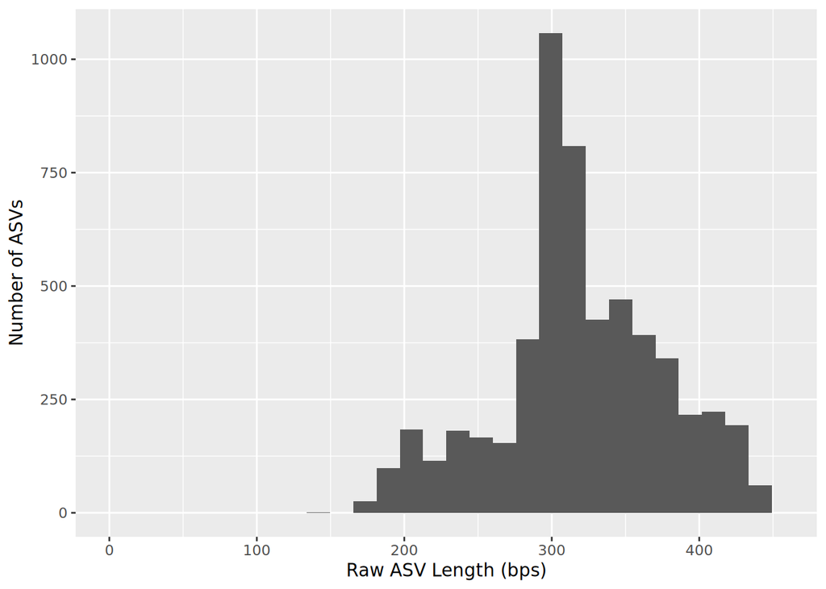

```r
# Inspect the distribution of sequence lengths of all ASVs in data set
plot_ASVLength_raw <-
  data.frame(Seq_Length = nchar(getSequences(raw_ASV_table))) %>%
  ggplot(aes(x = Seq_Length )) +
  geom_histogram() +
  # include the x-axis scales
  scale_x_continuous(limits = c(0, maxLength_ASV + 5)) +
  labs(y = "Number of ASVs", x = "Raw ASV Length (bps)")

# Show the plot
plot_ASVLength_raw
```

Preguntas 2: Cual es el largo esperado de los ASVs sin primers? Cual fue la region minima de solapamiento? Cual es el valor default de region minima de solapamiento? [En ITS es variable entonces queremos ver una curva con forma de campana, sobre todo que tenga un decrecimiento suavizado. La region minima de solapamiento fue 12 porque ese es el valor default de la funcion]

## Remover Chimeras

```r
# Remove the chimeras in the raw ASV table
noChimeras_ASV_table <-
  removeBimeraDenovo(raw_ASV_table,
                     method="consensus",
                     multithread = n_threads,
                     verbose=TRUE)
```

```
## Identified 92 bimeras out of 5496 input sequences.
```

```r
# Check the dimensions
dim(noChimeras_ASV_table)
```

```
## [1]   34 5404
```

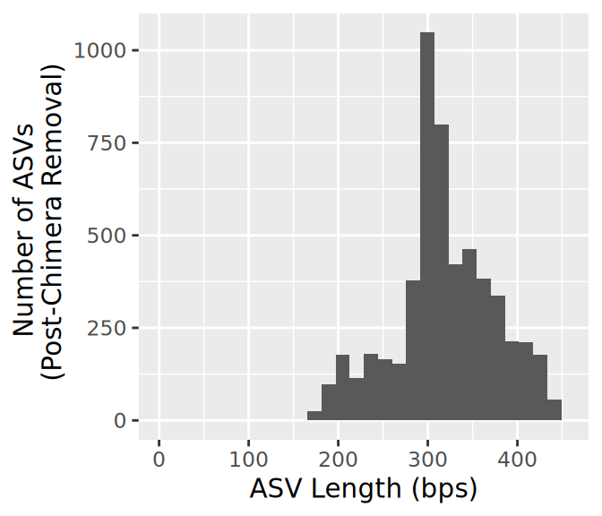

```r
# Chimera removal compared to raw
percRetained_chimerasRaw <-sum(noChimeras_ASV_table)/sum(raw_ASV_table)

# Plot it
plot_ASVLength_NoChimeras <-
  data.frame(Seq_Length_NoChim = nchar(getSequences(noChimeras_ASV_table))) %>%
  ggplot(aes(x = Seq_Length_NoChim )) +
  geom_histogram()+
  # include the x-axis scales
  scale_x_continuous(limits = c(0, maxLength_ASV + 5)) +
  labs(y = "Number of ASVs \n (Post-Chimera Removal)",
       x = "ASV Length (bps)")

# Show the plot
plot_ASVLength_NoChimeras
```

## Plot ASV Lengths

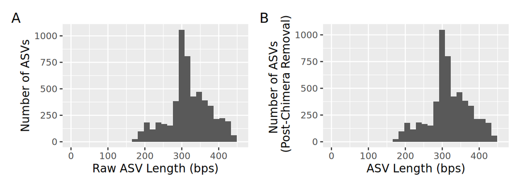

```r
plot_ASVLength_raw + plot_ASVLength_NoChimeras +
    plot_annotation(tag_levels = 'A')
```

## Track the read counts

```r
# A little function to identify number seqs
getN <- function(x) sum(getUniques(x))

# Make the table to track the seqs
track <- cbind(sapply(dada_forward, getN),
               sapply(dada_reverse, getN),
               sapply(merged_ASVs, getN),
               rowSums(noChimeras_ASV_table))
```

[output not shown]

```r
head(track)
```

```
##                               [,1]  [,2]  [,3]  [,4]
## ANF-004_R1_filtered.fastq.gz 73402 73641 71311 71185
## ANF-006_R1_filtered.fastq.gz 72798 72851 71122 71096
## ANF-007_R1_filtered.fastq.gz 47684 47812 45836 45174
## ANF-011_R1_filtered.fastq.gz 59447 59385 56475 56463
## ANF-018_R1_filtered.fastq.gz 49819 49826 48427 48371
## ANF-021_R1_filtered.fastq.gz 59299 59369 58241 58238
```

```r
# Update column names to be more informative (most are missing at the moment!)
colnames(track) <- c("denoisedF", "denoisedR", "merged", "nochim")
rownames(track) <- row.names(noChimeras_ASV_table)

# Generate a dataframe to track the reads through our DADA2 pipeline
track_counts_df <-
  track %>%
  # make it a dataframe
  as.data.frame() %>%
  rownames_to_column(var = "sample_names")

# Now let's add a column for the number of ASVs
# First, intuition check that the samples match
stopifnot(track_counts_df$sample_names == row.names(noChimeras_ASV_table))

# Now, let's add a new column with the number of ASVs
track_counts_df <-
  track_counts_df %>%
  mutate(num_ASVs = rowSums(noChimeras_ASV_table > 1))

# Visualize it in table format
DT::datatable(track_counts_df)
```

|  | sample_names | denoisedF | denoisedR | merged | nochim | num_ASVs |
| --- | --- | --- | --- | --- | --- | --- |
| 1 | ANF-004_R1_filtered.fastq.gz | 73402 | 73641 | 71311 | 71185 | 266 |
| 2 | ANF-006_R1_filtered.fastq.gz | 72798 | 72851 | 71122 | 71096 | 143 |
| 3 | ANF-007_R1_filtered.fastq.gz | 47684 | 47812 | 45836 | 45174 | 193 |
| 4 | ANF-011_R1_filtered.fastq.gz | 59447 | 59385 | 56475 | 56463 | 308 |
| 5 | ANF-018_R1_filtered.fastq.gz | 49819 | 49826 | 48427 | 48371 | 215 |
| 6 | ANF-021_R1_filtered.fastq.gz | 59299 | 59369 | 58241 | 58238 | 307 |
| 7 | ANF-023_R1_filtered.fastq.gz | 57855 | 57848 | 57697 | 57697 | 120 |
| 8 | ANF-026_R1_filtered.fastq.gz | 51494 | 51569 | 51038 | 50933 | 198 |
| 9 | ANF-034_R1_filtered.fastq.gz | 74255 | 74379 | 71289 | 71193 | 158 |
| 10 | ANF-042_R1_filtered.fastq.gz | 47707 | 47732 | 43604 | 43604 | 89 |

[output cut: 24 more lines]

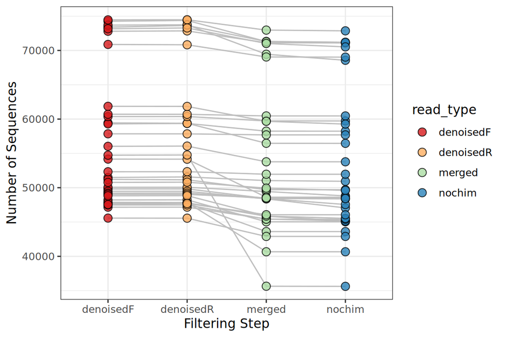

```r
# Plot it!
track_counts_df %>%
  pivot_longer(denoisedF:nochim, names_to = "read_type", values_to = "num_reads") %>%
  mutate(read_type = fct_relevel(read_type, "denoisedF", "denoisedR", "merged", "nochim")) %>%
  ggplot(aes(x = read_type, y = num_reads, fill = read_type)) +
  geom_line(aes(group = sample_names), color = "grey") +
  geom_point(shape = 21, size = 3, alpha = 0.8) +
  scale_fill_brewer(palette = "Spectral") +
  labs(x = "Filtering Step", y = "Number of Sequences") +
  theme_bw()
```

## Profundidad, riqueza y ASVs por profundidad

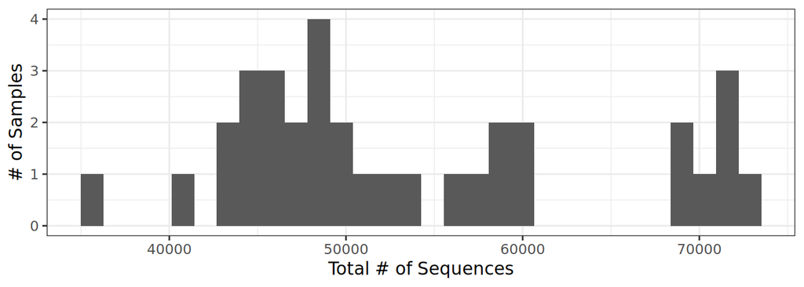

```r
# Cual es la profundidad por muestra
plot_ReadDepth <-
  track_counts_df %>%
  ggplot(aes(x = nochim)) +
  geom_histogram() +
  labs(x = "Total # of Sequences", y = "# of Samples") +
  theme_bw()
plot_ReadDepth
```

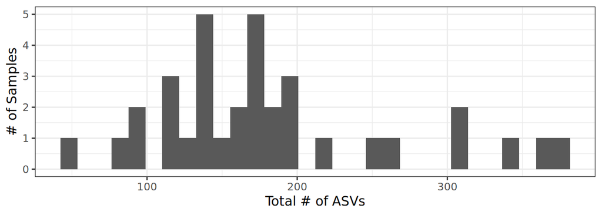

```r
# What is the ASV richness per sample?
plot_ASVRichness <-
  track_counts_df %>%
  ggplot(aes(x = num_ASVs)) +
  geom_histogram() +
  labs(x = "Total # of ASVs", y = "# of Samples") +
  theme_bw()
plot_ASVRichness
```

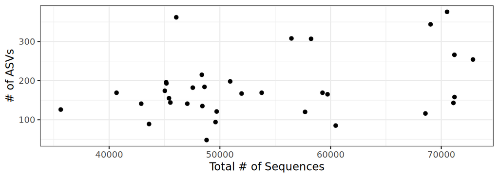

```r
# Now, let's look at the relationship of ASVs and Sequencing depth
plot_ReadDepth_ASVRichness <-
  track_counts_df %>%
  ggplot(aes(x = nochim, y = num_ASVs)) +
  geom_point() +
  labs(x = "Total # of Sequences", y = "# of ASVs") +
  theme_bw()
plot_ReadDepth_ASVRichness
```

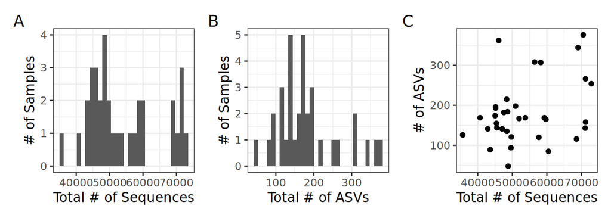

```r
# Show the plots together
plot_ReadDepth + plot_ASVRichness + plot_ReadDepth_ASVRichness +
    plot_annotation(tag_levels = 'A')
```

Preguntas 3: Que proporcion de los ASVs se mantuvo despues de quitar quimeras? Hay algun detalle adicional en relacion a la retencion de muestras que puedas mencionar?

[La mayoria de ASVs se retuvieron despues de eliminar quimeras y la mayoria de las muestras tienen alrededor de 50k reads, adicional no parece haber ninguna relacion entre la profundidad de secuenciamiento y el numero de ASVs, algo que da mas seguridad al analisis]

# Asignar taxonomia

```r
# Assign taxonomy
taxa_train <-
  assignTaxonomy(noChimeras_ASV_table,
                 refFasta = "/opt/curso_16s/bases_de_datos/amplicones/sh_general_release_unite_all_19.02.2025.fasta",
                 tryRC = TRUE,
                 multithread = n_threads)
```

```
## UNITE fungal taxonomic reference detected.
```

```r
# Inspect the taxonomy
glimpse(taxa_train) # Note that the rownames are the ASV sequences!
```

```
##  chr [1:5404, 1:7] "k__Fungi" "k__Fungi" "k__Fungi" "k__Fungi" NA ...
##  - attr(*, "dimnames")=List of 2
##   ..$ : chr [1:5404] "GAAACGCGATATGTAATGTGAATTGCAGAATTCAGTGAATCATCGAATCTTTGAACGCACATGGCGCCTTCCAGTATCCTGGGAGGCATGCCTGTCCGAGCGTCGTTTCAA"| __truncated__ "GAAATGCGATAAGTAATGTGAATTGCAGAATTCAGTGAATCATCGAATCTTTGAACGCACATTGCGCCCCCTGGTATTCCGGGGGGCATGCCTGTTCGAGCGTCATTTCAC"| __truncated__ "GAAATGCGATAAGTAAT…
##   ..$ : chr [1:7] "Kingdom" "Phylum" "Class" "Order" ...
```

```r
# Let's removing the ASV sequence rownames for display only
taxa_print <- taxa_train
rownames(taxa_print) <- NULL
head(taxa_print)
```

```
##      Kingdom    Phylum             Class                   Order
## [1,] "k__Fungi" "p__Ascomycota"    "c__Sordariomycetes"    "o__Glomerellales"
## [2,] "k__Fungi" "p__Ascomycota"    "c__Dothideomycetes"    "o__Cladosporiales"
## [3,] "k__Fungi" "p__Basidiomycota" "c__Microbotryomycetes" "o__Sporidiobolales"
## [4,] "k__Fungi" "p__Mucoromycota"  "c__Mucoromycetes"      "o__Mucorales"
## [5,] NA         NA                 NA                      NA
## [6,] "k__Fungi" "p__Basidiomycota" "c__Microbotryomycetes" "o__Sporidiobolales"
##      Family                    Genus                 Species
## [1,] "f__Plectosphaerellaceae" "g__Plectosphaerella" "s__plurivora"
## [2,] "f__Cladosporiaceae"      "g__Cladosporium"     "s__herbarum"
## [3,] "f__Sporidiobolaceae"     "g__Rhodotorula"      "s__mucilaginosa"
## [4,] "f__Mucoraceae"           "g__Mucor"            "s__genevensis"
## [5,] NA                        NA                    NA
## [6,] "f__Sporidiobolaceae"     "g__Rhodotorula"      "s__mucilaginosa"
```

```r
#View(taxa_print)
```

# Exportar la data

## 1. ASV Tables

```r
# What's the current format of the ASV table?
head(rownames(noChimeras_ASV_table)) # Samples!
```

```
## [1] "ANF-004_R1_filtered.fastq.gz" "ANF-006_R1_filtered.fastq.gz"
## [3] "ANF-007_R1_filtered.fastq.gz" "ANF-011_R1_filtered.fastq.gz"
## [5] "ANF-018_R1_filtered.fastq.gz" "ANF-021_R1_filtered.fastq.gz"
```

```r
head(colnames(noChimeras_ASV_table)) # ASV Sequences
```

```
## [1] "GAAACGCGATATGTAATGTGAATTGCAGAATTCAGTGAATCATCGAATCTTTGAACGCAC…"
## [2] "GAAATGCGATAAGTAATGTGAATTGCAGAATTCAGTGAATCATCGAATCTTTGAACGCAC…"
## [3] "GAAATGCGATAAGTAATGTGAATTGCAGAATTCAGTGAATCATCGAATCTTTGAACGCAC…"
## [4] "AAAGTGCGATAACTAGTGTGAATTGCATATTCAGTGAATCATCGAGTCTTTGAACGCAAC…"
## [5] "GTGGTTCCGGGTCTGTTGCATAAGTATAGCAATCGCGCCCTGTTACTGGTGAAAGGCGGG…"
## [6] "GAAATGCGATAAGTAATGTGAATTGCAGAATTCAGTGAATCATCGAATCTTTGAACGCAC…"
```

```r
# Transponer la matriz para poner seqs en rows y names en cols
final_ASV_table_withSeqs <- t(noChimeras_ASV_table)

# Intuition check
head(rownames(final_ASV_table_withSeqs)) # ASV Sequences
```

```
## [1] "GAAACGCGATATGTAATGTGAATTGCAGAATTCAGTGAATCATCGAATCTTTGAACGCAC…"
## [2] "GAAATGCGATAAGTAATGTGAATTGCAGAATTCAGTGAATCATCGAATCTTTGAACGCAC…"
## [3] "GAAATGCGATAAGTAATGTGAATTGCAGAATTCAGTGAATCATCGAATCTTTGAACGCAC…"
## [4] "AAAGTGCGATAACTAGTGTGAATTGCATATTCAGTGAATCATCGAGTCTTTGAACGCAAC…"
## [5] "GTGGTTCCGGGTCTGTTGCATAAGTATAGCAATCGCGCCCTGTTACTGGTGAAAGGCGGG…"
## [6] "GAAATGCGATAAGTAATGTGAATTGCAGAATTCAGTGAATCATCGAATCTTTGAACGCAC…"
```

```r
head(colnames(final_ASV_table_withSeqs)) # Sample names
```

```
## [1] "ANF-004_R1_filtered.fastq.gz" "ANF-006_R1_filtered.fastq.gz"
## [3] "ANF-007_R1_filtered.fastq.gz" "ANF-011_R1_filtered.fastq.gz"
## [5] "ANF-018_R1_filtered.fastq.gz" "ANF-021_R1_filtered.fastq.gz"
```

### Limpiar sample_names en la tabla

```r
# Remember at the top of the file we created a vector of sample names
head(sample_names)
```

```
## [1] "ANF-004" "ANF-006" "ANF-007" "ANF-011" "ANF-018" "ANF-021"
```

```r
# Let's check with the actual column names
head(colnames(final_ASV_table_withSeqs)) # Sample names
```

```
## [1] "ANF-004_R1_filtered.fastq.gz" "ANF-006_R1_filtered.fastq.gz"
## [3] "ANF-007_R1_filtered.fastq.gz" "ANF-011_R1_filtered.fastq.gz"
## [5] "ANF-018_R1_filtered.fastq.gz" "ANF-021_R1_filtered.fastq.gz"
```

```r
# And then apply our sample name script to check, too
head(sapply(strsplit(colnames(final_ASV_table_withSeqs), "_"), `[`,1)) # Looks good!
```

```
## [1] "ANF-004" "ANF-006" "ANF-007" "ANF-011" "ANF-018" "ANF-021"
```

```r
# Chequeo de intuicion para asegurarse que funciono
stopifnot(sapply(strsplit(colnames(final_ASV_table_withSeqs), "_"), `[`,1) == sample_names)

# Ahora vemos que el cambio de nombre no tendra errores asi que lo aplicamos
colnames(final_ASV_table_withSeqs) <- sample_names
head(colnames(final_ASV_table_withSeqs))
```

```
## [1] "ANF-004" "ANF-006" "ANF-007" "ANF-011" "ANF-018" "ANF-021"
```

### Renombrar ASVs a numeraciones

```r
# First pull the ASV sequences from the rownames
ASV_seqs <- rownames(final_ASV_table_withSeqs)
ASV_seqs[1:5]
```

```
## [1] "GAAACGCGATATGTAATGTGAATTGCAGAATTCAGTGAATCATCGAATCTTTGAACGCAC…"
## [2] "GAAATGCGATAAGTAATGTGAATTGCAGAATTCAGTGAATCATCGAATCTTTGAACGCAC…"
## [3] "GAAATGCGATAAGTAATGTGAATTGCAGAATTCAGTGAATCATCGAATCTTTGAACGCAC…"
## [4] "AAAGTGCGATAACTAGTGTGAATTGCATATTCAGTGAATCATCGAGTCTTTGAACGCAAC…"
## [5] "GTGGTTCCGGGTCTGTTGCATAAGTATAGCAATCGCGCCCTGTTACTGGTGAAAGGCGGG…"
```

```r
# How many ASVs?
num_ASVs <- dim(final_ASV_table_withSeqs)[1] # select the number of rows
num_ASVs
```

```
## [1] 5404
```

```r
# which is where we will place the new operational ASV names
ASV_headers <- vector(num_ASVs, mode = "character")

# Let's mae sure we have an empty vector!
ASV_headers[1:5]
```

```
## [1] "" "" "" "" ""
```

```r
length(ASV_headers) # looks good!
```

```
## [1] 5404
```

```r
# Ahora creemos un vector con ASVs numerados usando un loop
for (i in 1:num_ASVs) {
  # Add leading zero to ASV name so they print in correct order.
  ASV_number <- sprintf("%04d", i)
  # Now, rename each spot in the ASV header vector as we loop through the for loop
  ASV_headers[i] <- paste(">ASV", ASV_number, sep = "_")
}

# Intuition check
ASV_headers[1:5]
```

```
## [1] ">ASV_0001" ">ASV_0002" ">ASV_0003" ">ASV_0004" ">ASV_0005"
```

```r
# Create a new ASV table, which will have the ASV numbers as names
#View(noChimeras_ASV_table) # To view the table
final_ASV_table <- final_ASV_table_withSeqs
glimpse(final_ASV_table)
```

```
##  int [1:5404, 1:34] 0 3656 0 0 0 0 0 0 0 0 ...
##  - attr(*, "dimnames")=List of 2
##   ..$ : chr [1:5404] "GAAACGCGATATGTAATGTGAATTGCAGAATTCAGTGAATCATCGAATCTTTGAACGCACATGGCGCCTTCCAGTATCCTGGGAGGCATGCCTGTCCGAGCGTCGTTTCAA"| __truncated__ "GAAATGCGATAAGTAATGTGAATTGCAGAATTCAGTGAATCATCGAATCTTTGAACGCACATTGCGCCCCCTGGTATTCCGGGGGGCATGCCTGTTCGAGCGTCATTTCAC"| __truncated__ "GAAATGCGATAAGTAAT…
##   ..$ : chr [1:34] "ANF-004" "ANF-006" "ANF-007" "ANF-011" ...
```

```r
## Replace the ASV seqs with the ASV numbers
row.names(final_ASV_table) <- sub(">", "", ASV_headers)
final_ASV_table[1:5, 1:5]
```

```
##          ANF-004 ANF-006 ANF-007 ANF-011 ANF-018
## ASV_0001       0       0       0       0       0
## ASV_0002    3656    2060    3366     135   15039
## ASV_0003       0       0       0       0       0
## ASV_0004       0       0       0       0       0
## ASV_0005       0       0       0       0       0
```

```r
#View(final_ASV_table) # To view the table
```

### Escribir tablas de ASVs

```r
# 1. Write count table with ASV sequence names
write.table(final_ASV_table_withSeqs,
            file = "data/its/02_Assign_ASVs/ASV_table_withSeqNames.tsv",
            sep = "\t", quote = FALSE, col.names = NA)

# 2. Write count table with ASV numbered names (e.g. ASV_1, ASV_2, etc)
write.table(final_ASV_table,
            file = "data/its/02_Assign_ASVs/ASV_table.tsv",
            sep = "\t", quote = FALSE, col.names = NA)
```

## 2. Taxonomy Table

### Formatear la tabla

```r
# Inspect the taxonomy table
dim(taxa_train) # ASVs are in rows and Kingdom, Phylum, etc in Columns
```

```
## [1] 5404    7
```

```r
colnames(taxa_train) # Column names are Linnean Taxonomy
```

```
## [1] "Kingdom" "Phylum"  "Class"   "Order"   "Family"  "Genus"   "Species"
```

```r
head(rownames(taxa_train), n = 2) # ASV names are rownames
```

```
## [1] "GAAACGCGATATGTAATGTGAATTGCAGAATTCAGTGAATCATCGAATCTTTGAACGCAC…"
## [2] "GAAATGCGATAAGTAATGTGAATTGCAGAATTCAGTGAATCATCGAATCTTTGAACGCAC…"
```

```r
class(taxa_train) # Character matrix
```

```
## [1] "matrix" "array"
```

```r
##### Prepare tax table
# 1. Add the ASV sequences from the rownames to a column
new_tax_table <-
  taxa_train%>%
  as.data.frame() %>%
  rownames_to_column(var = "ASVseqs")

# Intuition check
glimpse(new_tax_table)
```

```
## Rows: 5,404
## Columns: 8
## $ ASVseqs <chr> "GAAACGCGATATGTAATGTGAATTGCAGAATTCAGTGAATCATCGAATCTTTGAACGCACA…
## $ Kingdom <chr> "k__Fungi", "k__Fungi", "k__Fungi", "k__Fungi", NA, "k__Fungi"…
## $ Phylum  <chr> "p__Ascomycota", "p__Ascomycota", "p__Basidiomycota", "p__Muco…
## $ Class   <chr> "c__Sordariomycetes", "c__Dothideomycetes", "c__Microbotryomyc…
## $ Order   <chr> "o__Glomerellales", "o__Cladosporiales", "o__Sporidiobolales",…
## $ Family  <chr> "f__Plectosphaerellaceae", "f__Cladosporiaceae", "f__Sporidiob…
## $ Genus   <chr> "g__Plectosphaerella", "g__Cladosporium", "g__Rhodotorula", "g…
## $ Species <chr> "s__plurivora", "s__herbarum", "s__mucilaginosa", "s__genevens…
```

```r
# Comprobar que no se mezclaron los nombres
stopifnot(new_tax_table$ASVseqs == rownames(final_ASV_table_withSeqs))

# Now let's add the ASV names
rownames(new_tax_table) <- rownames(final_ASV_table)
head(new_tax_table)
```

```
##                                                                                                                                                                                                                                                                                                          …
## ASV_0001                                                          GAAACGCGATATGTAATGTGAATTGCAGAATTCAGTGAATCATCGAATCTTTGAACGCAC…
## ASV_0002                                                                               GAAATGCGATAAGTAATGTGAATTGCAGAATTCAGTGAATCATCGAATCTTTGAACGCAC…
## ASV_0003           GAAATGCGATAAGTAATGTGAATTGCAGAATTCAGTGAATCATCGAATCTTTGAACGCAC…
## ASV_0004                   AAAGTGCGATAACTAGTGTGAATTGCATATTCAGTGAATCATCGAGTCTTTGAACGCAAC…
## ASV_0005 GTGGTTCCGGGTCTGTTGCATAAGTATAGCAATCGCGCCCTGTTACTGGTGAAAGGCGGG…
## ASV_0006           GAAATGCGATAAGTAATGTGAATTGCAGAATTCAGTGAATCATCGAATCTTTGAACGCAC…
##           Kingdom           Phylum                 Class              Order
## ASV_0001 k__Fungi    p__Ascomycota    c__Sordariomycetes   o__Glomerellales
## ASV_0002 k__Fungi    p__Ascomycota    c__Dothideomycetes  o__Cladosporiales
## ASV_0003 k__Fungi p__Basidiomycota c__Microbotryomycetes o__Sporidiobolales
## ASV_0004 k__Fungi  p__Mucoromycota      c__Mucoromycetes       o__Mucorales
## ASV_0005     <NA>             <NA>                  <NA>               <NA>
## ASV_0006 k__Fungi p__Basidiomycota c__Microbotryomycetes o__Sporidiobolales
##                           Family               Genus         Species
## ASV_0001 f__Plectosphaerellaceae g__Plectosphaerella    s__plurivora
## ASV_0002      f__Cladosporiaceae     g__Cladosporium     s__herbarum
## ASV_0003     f__Sporidiobolaceae      g__Rhodotorula s__mucilaginosa
## ASV_0004           f__Mucoraceae            g__Mucor   s__genevensis
## ASV_0005                    <NA>                <NA>            <NA>
## ASV_0006     f__Sporidiobolaceae      g__Rhodotorula s__mucilaginosa
```

```r
### Final prep of tax table. Add new column with ASV names
ASV_tax_table <-
  new_tax_table %>%
  # add rownames from count table for phyloseq handoff
  mutate(ASV = rownames(final_ASV_table)) %>%
  # Reorder the columns
  dplyr::select(Kingdom, Phylum, Class, Order, Family, Genus, Species, ASV, ASVseqs)

# Assign the rownames, which is required by phyloseq
rownames(ASV_tax_table) <- ASV_tax_table$ASV

# Take a quick look
glimpse(ASV_tax_table)
```

```
## Rows: 5,404
## Columns: 9
## $ Kingdom <chr> "k__Fungi", "k__Fungi", "k__Fungi", "k__Fungi", NA, "k__Fungi"…
## $ Phylum  <chr> "p__Ascomycota", "p__Ascomycota", "p__Basidiomycota", "p__Muco…
## $ Class   <chr> "c__Sordariomycetes", "c__Dothideomycetes", "c__Microbotryomyc…
## $ Order   <chr> "o__Glomerellales", "o__Cladosporiales", "o__Sporidiobolales",…
## $ Family  <chr> "f__Plectosphaerellaceae", "f__Cladosporiaceae", "f__Sporidiob…
## $ Genus   <chr> "g__Plectosphaerella", "g__Cladosporium", "g__Rhodotorula", "g…
## $ Species <chr> "s__plurivora", "s__herbarum", "s__mucilaginosa", "s__genevens…
## $ ASV     <chr> "ASV_0001", "ASV_0002", "ASV_0003", "ASV_0004", "ASV_0005", "A…
## $ ASVseqs <chr> "GAAACGCGATATGTAATGTGAATTGCAGAATTCAGTGAATCATCGAATCTTTGAACGCACA…
```

```r
# Intution check
stopifnot(ASV_tax_table$ASV == rownames(ASV_tax_table),
          rownames(ASV_tax_table) == rownames(ASV_tax_table))
```

## Guardar la tabla

```r
# Write the table
write.table(ASV_tax_table,
            file = "data/its/02_Assign_ASVs/ASV_taxonomy.tsv",
            sep = "\t", quote = FALSE, col.names = NA)
```

## 3. Creacion de objeto phyloseq

### Importar metadata y agregar las calidades de agua a las muestras

```r
# Importar la tabla de promedios de calidad de agua
agua_df <- read_csv("data/its/metadata/agua_promedios.csv", col_names = TRUE) %>%
  clean_names()
# Estandarizar los nombres de las muestras
track_counts_df$sample_names <- sapply(strsplit(track_counts_df$sample_names, "_"), '[', 1)

# Como se ve despues?
head(track_counts_df)
```

```
##   sample_names denoisedF denoisedR merged nochim num_ASVs
## 1      ANF-004     73402     73641  71311  71185      266
## 2      ANF-006     72798     72851  71122  71096      143
## 3      ANF-007     47684     47812  45836  45174      193
## 4      ANF-011     59447     59385  56475  56463      308
## 5      ANF-018     49819     49826  48427  48371      215
## 6      ANF-021     59299     59369  58241  58238      307
```

```r
# Ensamblar la metadata
metadata_fixed <-read_csv("data/its/metadata/metadata.csv", col_names = TRUE) %>%
  clean_names() %>%
  # Renombrar la columna de nombres para que sea sample_names
  dplyr::rename(sample_names = codigo) %>%

  # Elimina las filas que no tenian muestras secuenciadas
  drop_na(sample_names) %>%

  # Eliminar filas que tengan guiones bajos pero no codigo de muestra
  filter(!str_detect(sample_names, "^_+$|^-+$")) %>%

  # Estandarizar el nombre de las muestras
  mutate(sample_names = str_replace_all(sample_names, " ", "-")) %>%
  mutate(sample_names = str_trim(sample_names)) %>%
  # Inyectar las calidades promedio de agua por localidad
  left_join(agua_df, by = "localidad") %>%

  # Inner_join para ignorar las cosas no secuenciadas y añadir stats DADA2
  inner_join(track_counts_df, by = "sample_names") %>%

  # Prueba de sanidad para que solo haya un registro por muestra
  distinct(sample_names, .keep_all = TRUE) %>%

  # Phyloseq exige que los identificadores de muestra estén asignados como 'rownames'
  # para poder ensamblar el objeto S4. Sin embargo, las herramientas de Tidyverse
  # (como dplyr y ggplot2) operan sobre columnas explícitas y no leen los rownames.
  # Como la función 'column_to_rownames' consume (elimina) la columna que se le pasa,
  # creamos una copia temporal para sacrificarla en este paso. Esto satisface el
  # requisito de Phyloseq y conserva la columna original 'sample_names' intacta
  # para uso futuro en tidyverse y facil acceso a la metadata
  mutate(rownames_temp = sample_names) %>%
  column_to_rownames(var = "rownames_temp")
```

[output not shown]

```r
# Verificar dimensiones finales
dim(metadata_fixed)
```

```
## [1] 34 89
```

### Pasar a phyloseq

```r
raw_physeq <-
  phyloseq::phyloseq(otu_table(final_ASV_table, taxa_are_rows = TRUE),
         sample_data(metadata_fixed),
         tax_table(as.matrix(ASV_tax_table)))

raw_physeq
```

```
## phyloseq-class experiment-level object
## otu_table()   OTU Table:         [ 5404 taxa and 34 samples ]
## sample_data() Sample Data:       [ 34 samples by 89 sample variables ]
## tax_table()   Taxonomy Table:    [ 5404 taxa by 9 taxonomic ranks ]
```

```r
#save
save(raw_physeq, file = "data/its/02_Assign_ASVs/raw_physeq.RData")
```

# Final info for Reproducibility

## Check Render Time

```r
# Take the time now that we are at the end of the script
end_time <- Sys.time()
end_time
```

```
## [1] "2026-09-15 19:03:38 UTC"
```

```r
# Echo the elapsed time
elapsed_time <- round((end_time - start_time), 3)
elapsed_time
```

```
## Time difference of 1.127 hours
```